# Predictions using the Human Activity Recognition Dataset

Csaba Iranyi

## The Question

Using devices such as Jawbone Up, Nike FuelBand, and Fitbit it is now possible to collect a large amount of data about personal activity relatively inexpensively. These type of devices are part of the quantified self movement – a group of enthusiasts who take measurements about themselves regularly to improve their health, to find patterns in their behavior, or because they are tech geeks. One thing that people regularly do is quantify how much of a particular activity they do, but they rarely quantify how well they do it.

In this project, I will be to use data from accelerometers on the belt, forearm, arm, and dumbell of 6 participants.  
Six young health participants were asked to perform one set of 10 repetitions of the Unilateral Dumbbell Biceps Curl in five different fashions:

| Movement type | Class |
| --- | --- |
| Exactly according to the specification | Class A |
| Throwing the elbows to the front | Class B |
| Lifting the dumbbell only halfway | Class C |
| Lowering the dumbbell only halfway | Class D |
| Throwing the hips to the fron | Class E |

Based on a dataset provide by Human Activity Recognition (HAR) http://web.archive.org/web/20161224072740/http:/groupware.les.inf.puc-rio.br/har I will try:

- to train and evaluate some multi-class classification predictive models using the training dataset with 159 features and one label (classe),
- to use the trained prediction models to predict 20 different test cases (what exercise was performed) from the testing dataset.

## Getting data

```r
knitr::opts_chunk$set(echo = TRUE, warning = FALSE, message = FALSE, fig.width=10, fig.height=5)
options(width=120)

library(caret)
library(randomForest)
library(ggcorrplot)
library(ggpubr)
```

Downloading of traning and testing datasets.

```r
# Downloading training dataset
training.data <- read.table(file = "https://d396qusza40orc.cloudfront.net/predmachlearn/pml-training.csv",
                            header = TRUE,
                            sep = ",",
                            encoding = "ISO_8859-1")

# Downloading training dataset
testing.data <- read.table(file = "https://d396qusza40orc.cloudfront.net/predmachlearn/pml-testing.csv",
                           header = TRUE,
                           sep = ",",
                           encoding = "ISO_8859-1")
```

## Exploratory data analysis

Examining the dimensions and the features of the training dataset.

```r
# Number of features
cat("Number of features in training dataset:", length(names(training.data)) - 1, "\n")
```

```
## Number of features in training dataset: 159
```

```r
cat("Number of features in testing dataset:", length(names(training.data)) - 1, "\n")
```

```
## Number of features in testing dataset: 159
```

```r
# Number of rows
cat("Number of observations in training dataset:", nrow(training.data), "\n")
```

```
## Number of observations in training dataset: 19622
```

```r
cat("Number of observations in testing dataset:", nrow(testing.data), "\n")
```

```
## Number of observations in testing dataset: 20
```

```r
# Create summary of features (and label)
feature.summary <- data.frame(row.names = 1:length(names(training.data)))
feature.summary$feature.index <- 1:length(names(training.data))
feature.summary$feature.name <- names(training.data)
feature.summary$type <- sapply(training.data, class)
feature.summary$NA.rows <- sapply(training.data, function(x) sum(is.na(x)))
feature.summary$NA.rows.percent <- sapply(training.data, function(x) round(sum(is.na(x)) / length(x) * 100.0, digits = 2))
feature.summary$empty.rows <- sapply(training.data, function(x) length(x[x == ""]))
feature.summary$empty.rows.percent <- sapply(training.data, function(x) round(length(x[x == ""]) / length(x) * 100.0, digits = 2))
feature.summary$unique.values <- sapply(training.data, function(x) length(unique(x)))
feature.summary[, -1]
```

```
##                 feature.name    type NA.rows NA.rows.percent empty.rows empty.rows.percent unique.values
## 1                          X integer       0            0.00          0               0.00         19622
## 2                  user_name  factor       0            0.00          0               0.00             6
## 3       raw_timestamp_part_1 integer       0            0.00          0               0.00           837
## 4       raw_timestamp_part_2 integer       0            0.00          0               0.00         16783
## 5             cvtd_timestamp  factor       0            0.00          0               0.00            20
## 6                 new_window  factor       0            0.00          0               0.00             2
## 7                 num_window integer       0            0.00          0               0.00           858
## 8                  roll_belt numeric       0            0.00          0               0.00          1330
## 9                 pitch_belt numeric       0            0.00          0               0.00          1840
## 10                  yaw_belt numeric       0            0.00          0               0.00          1957
## 11          total_accel_belt integer       0            0.00          0               0.00            29
## 12        kurtosis_roll_belt  factor       0            0.00      19216              97.93           397
## 13       kurtosis_picth_belt  factor       0            0.00      19216              97.93           317
## 14         kurtosis_yaw_belt  factor       0            0.00      19216              97.93             2
```

[output cut: 146 more lines]

Lot of features has either NA or empty values in great percent.

## Cleaning data

### Removing useless features

Removing constant features and features with NA or empty rows from the training and testing data as well.

```r
# Removing useless features
#  - Constant features
#  - Features with NA rows
#  - Features with empty rows
useless.feature.indices <- feature.summary[feature.summary$unique.values == 1 | feature.summary$NA.rows != 0 | feature.summary$empty.rows !=0, 1]
cat("Number of removable useless features:", length(useless.feature.indices), "\n")
```

```
## Number of removable useless features: 100
```

```r
training.data <- training.data[, -useless.feature.indices]
testing.data <- testing.data[, -useless.feature.indices]
```

### Removing unnecessary features

Removing the sequence feature (X) and all time related features () from the training and testing data.

```r
# Removing unnecessary features
unnecessary.feature.indices <- grep("timestamp|X", names(training.data))
cat("Number of removable unnecessary features:", length(unnecessary.feature.indices), "\n")
```

```
## Number of removable unnecessary features: 4
```

```r
training.data <- training.data[, -unnecessary.feature.indices]
testing.data <- testing.data[, -unnecessary.feature.indices]
```

### Converting features

Converting all features to numeric type (except the label column).

```r
# Converting all features to numeric type (except the label column)
label.column <- training.data$classe
training.data <- data.frame(data.matrix(training.data))
training.data$classe <- label.column
testing.data <- data.frame(data.matrix(testing.data))

# Number of usable features
cat("Number of usable features:", length(names(training.data)) - 1, "\n")
```

```
## Number of usable features: 55
```

## Splitting data

The downloaded test dataset (20 observations) is the the ultimate validation set (one time scoring).  
Splitting up the downloaded training dataset into a cross-validating (25%) and training dataset (75%).

```r
# Initialize RNG
set.seed(333)

# Crete training/CV datasets
partition.indices <- createDataPartition(y = training.data$classe, p = 0.75, list = FALSE)
cv.data <- training.data[-partition.indices,]
training.data <- training.data[partition.indices,]

cat("Number of rows in training dataset:", nrow(training.data), "\n")
```

```
## Number of rows in training dataset: 14718
```

```r
cat("Number of rows in cross-validation dataset:", nrow(cv.data), "\n")
```

```
## Number of rows in cross-validation dataset: 4904
```

```r
cat("Number of rows in testing dataset:", nrow(testing.data), "\n")
```

```
## Number of rows in testing dataset: 20
```

## Feature engineering

### Finding feature correlations

Calculating feature correlations with the outcome (classe).

```r
# Label (outcome) column index
label.index <- which(names(training.data) == "classe")

# Create summary of usable features
feature.set <- training.data[,-label.index]
feature.summary <- data.frame(row.names = 1:length(names(feature.set)))
feature.summary$feature.index <- 1:length(names(feature.set))
feature.summary$feature.name <- names(feature.set)
feature.summary$type <- sapply(feature.set, class)
feature.summary$unique <- sapply(feature.set, function(x) length(unique(x)))
feature.summary$mean <- sapply(feature.set, function(x) round(mean(x), digits = 4))
feature.summary$sum <- sapply(feature.set, function(x) round(sum(x), digits = 4))
feature.summary$sd <- sapply(feature.set, function(x) round(sd(x), digits = 4))
feature.summary$cor <- sapply(feature.set, function(x) round(abs(cor(x, as.numeric(training.data$classe))), digits = 4))
feature.summary <- feature.summary[order(feature.summary$cor, decreasing = TRUE),]
feature.summary[, -1]
```

```
##            feature.name    type unique      mean         sum       sd    cor
## 44        pitch_forearm numeric   2681   10.7231   157822.40  28.0715 0.3437
## 27         magnet_arm_x numeric   1323  193.8237  2852697.00 443.2437 0.2987
## 15        magnet_belt_y numeric    288  593.7373  8738625.00  35.0887 0.2817
## 28         magnet_arm_y numeric    857  156.1741  2298570.00 201.4303 0.2543
## 24          accel_arm_x numeric    767  -59.7171  -878917.00 182.5694 0.2403
## 50      accel_forearm_x numeric    785  -62.6650  -922303.00 181.1984 0.1874
## 53     magnet_forearm_x numeric   1463 -313.3946 -4612542.00 345.9312 0.1768
## 18            pitch_arm numeric   2858   -4.6924   -69062.66  30.7253 0.1759
## 16        magnet_belt_z numeric    437 -345.4974 -5085030.00  64.7346 0.1712
## 46  total_accel_forearm numeric     67   34.7744   511809.00  10.0465 0.1565
## 29         magnet_arm_z numeric   1258  306.6023  4512572.00 326.5414 0.1519
## 42    magnet_dumbbell_z numeric    665   45.9814   676754.60 140.1708 0.1482
## 20      total_accel_arm numeric     66   25.5113   375476.00  10.4827 0.1201
## 54     magnet_forearm_y numeric   1836  378.7137  5573907.88 510.6675 0.1162
```

[output cut: 41 more lines]

Selecting 33 (manually choosen number) features with best correlations with outcome.

```r
# The most relevant features (best correlations with outcome)
most.correlated.outcome.feature.indices <- feature.summary$feature.index[1:33]
cat("Relevant features:", feature.summary$feature.name[1], "...", feature.summary$feature.name[33], "\n")
```

```
## Relevant features: pitch_forearm ... num_window
```

Searching for duplicated (lineary dependent) features to reduce pair-wise correlations.

```r
# Duplicated feature
feature.correlation.matrix <- cor(training.data[, -label.index])
duplicated.feature.indices <- findCorrelation(feature.correlation.matrix, cutoff = 0.9, exact = TRUE)
cat("Removable duplicated features:", paste(names(training.data)[duplicated.feature.indices], collapse = ", "), "\n")
```

```
## Removable duplicated features: accel_belt_z, roll_belt, accel_belt_y, accel_belt_x, gyros_dumbbell_x, gyros_dumbbell_z, gyros_arm_x
```

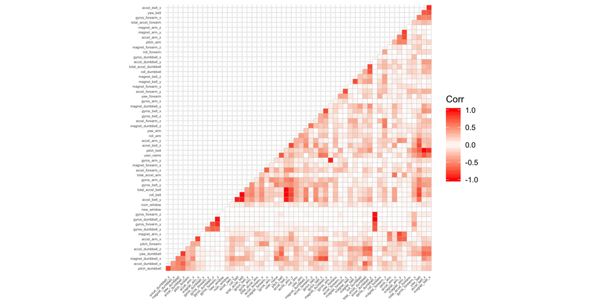

```r
# Plot correlation matrix
ggcorrplot(feature.correlation.matrix, hc.order = TRUE, type = "lower", colors = c("red", "white", "red"), insig = "blank", tl.cex = list(size = 4))
```

## Training and scoring models

Creating a summary dataset to store result of trained models.

```r
# Summary of models
model.summary <- data.frame(row.names = 1:6, stringsAsFactors = TRUE)

# Initialize RNG
set.seed(333)
```

Setting options of random forest.

```r
# Number of trees
number.trees <- 50
```

### Random Forest: using all features

```r
# Random Forest: all features
start.time <- Sys.time()
model.all.features <- randomForest(
  x = training.data[, -label.index],
  y = training.data$classe,
  xtest = cv.data[, -label.index],
  ytest = cv.data$classe,
  ntree = number.trees,
  keep.forest = TRUE,
  proximity = TRUE,
  do.trace = FALSE)
end.time <- Sys.time()

model.summary <- rbind(model.summary, cbind(
  trees = model.all.features$ntree,
  features = ncol(training.data) - 1,
  model = "All features",
  training.accuracy = round((1 - sum(model.all.features$confusion[,"class.error"])) * 100, digits = 3),
  cv.accuracy =round((1 - sum(model.all.features$test$confusion[,"class.error"])) * 100, digits = 3),
  training.time = round(as.numeric(end.time - start.time, units = "secs"))
))
```

### Random Forest: all features with PCA

```r
# Apply PCA
pre.pca <- preProcess(training.data[, -label.index], method = "pca", thresh = 0.99)
training.data.pca <- predict(pre.pca, training.data[, -label.index])
cv.data.pca <- predict(pre.pca, cv.data[, -label.index])
testing.data.pca <- predict(pre.pca, testing.data[, -label.index])

# Random Forest: all feature with PCA
start.time <- Sys.time()
model.pca.features <- randomForest(
  x = training.data.pca,
  y = training.data$classe,
  xtest = cv.data.pca,
  ytest = cv.data$classe,
  ntree = number.trees,
  keep.forest = TRUE,
  proximity = TRUE,
  do.trace = FALSE)
end.time <- Sys.time()

model.summary <- rbind(model.summary, cbind(
  trees = model.pca.features$ntree,
  features = ncol(training.data.pca),
  model = "PCA",
  training.accuracy = round((1 - sum(model.pca.features$confusion[,"class.error"])) * 100, digits = 3),
  cv.accuracy = round((1 - sum(model.pca.features$test$confusion[,"class.error"])) * 100, digits = 3),
  training.time = round(as.numeric(end.time - start.time, units = "secs"))
))
```

### Random Forest: the most correlated features

```r
# Random Forest: the most correlated features
start.time <- Sys.time()
model.corr.features <- randomForest(
  x = training.data[, most.correlated.outcome.feature.indices],
  y = training.data$classe,
  xtest = cv.data[, most.correlated.outcome.feature.indices],
  ytest = cv.data$classe,
  ntree = number.trees,
  keep.forest = TRUE,
  proximity = TRUE,
  do.trace = FALSE)
end.time <- Sys.time()

model.summary <- rbind(model.summary, cbind(
  trees = model.corr.features$ntree,
  features = ncol(training.data[, most.correlated.outcome.feature.indices]),
  model = "Correlated",
  training.accuracy = round((1 - sum(model.corr.features$confusion[,"class.error"])) * 100, digits = 3),
  cv.accuracy = round((1 - sum(model.corr.features$test$confusion[,"class.error"])) * 100, digits = 3),
  training.time = round(as.numeric(end.time - start.time, units = "secs"))
))
```

### Random Forest: the most correlated features with PCA

```r
# Apply PCA
pre.corr.pca <- preProcess(training.data[, most.correlated.outcome.feature.indices], method = "pca", thresh = 0.99)
training.data.corr.pca <- predict(pre.corr.pca, training.data[, most.correlated.outcome.feature.indices])
cv.data.corr.pca <- predict(pre.corr.pca, cv.data[, most.correlated.outcome.feature.indices])
testing.data.corr.pca <- predict(pre.corr.pca, testing.data[, most.correlated.outcome.feature.indices])

# Random Forest: the most correlated features with PCA
start.time <- Sys.time()
model.corr.pca.features <- randomForest(
  x = training.data.corr.pca,
  y = training.data$classe,
  xtest = cv.data.corr.pca,
  ytest = cv.data$classe,
  ntree = number.trees,
  keep.forest = TRUE,
  proximity = TRUE,
  do.trace = FALSE)
end.time <- Sys.time()

model.summary <- rbind(model.summary, cbind(
  trees = model.corr.pca.features$ntree,
  features = ncol(training.data.corr.pca),
  model = "Correlated + PCA",
  training.accuracy = round((1 - sum(model.corr.pca.features$confusion[,"class.error"])) * 100, digits = 3),
  cv.accuracy = round((1 - sum(model.corr.pca.features$test$confusion[,"class.error"])) * 100, digits = 3),
  training.time = round(as.numeric(end.time - start.time, units = "secs"))
))
```

### Random Forest: reduced features

```r
# Random Forest: reduced features
start.time <- Sys.time()
model.reduced.features <- randomForest(
  x = training.data[, -c(duplicated.feature.indices, label.index)],
  y = training.data$classe,
  xtest = cv.data[, -c(duplicated.feature.indices, label.index)],
  ytest = cv.data$classe,
  ntree = number.trees,
  keep.forest = TRUE,
  proximity = TRUE,
  do.trace = FALSE)
end.time <- Sys.time()

model.summary <- rbind(model.summary, cbind(
  trees = model.reduced.features$ntree,
  features = ncol(training.data[, -c(duplicated.feature.indices, label.index)]),
  model = "Reduced",
  training.accuracy = round((1 - sum(model.reduced.features$confusion[,"class.error"])) * 100, digits = 3),
  cv.accuracy = round((1 - sum(model.reduced.features$test$confusion[,"class.error"])) * 100, digits = 3),
  training.time = round(as.numeric(end.time - start.time, units = "secs"))
))
```

### Random Forest: reduced features with PCA

```r
# Apply PCA
pre.reduced.pca <- preProcess(training.data[, -c(duplicated.feature.indices, label.index)], method = "pca", thresh = 0.99)
training.data.reduced.pca <- predict(pre.reduced.pca, training.data[, -c(duplicated.feature.indices, label.index)])
cv.data.reduced.pca <- predict(pre.reduced.pca, cv.data[, -c(duplicated.feature.indices, label.index)])
testing.data.reduced.pca <- predict(pre.reduced.pca, testing.data[, -c(duplicated.feature.indices, label.index)])

# Random Forest: reduced features with PCA
start.time <- Sys.time()
model.reduced.pca.features <- randomForest(
  x = training.data.reduced.pca,
  y = training.data$classe,
  xtest = cv.data.reduced.pca,
  ytest = cv.data$classe,
  ntree = number.trees,
  keep.forest = TRUE,
  proximity = TRUE,
  do.trace = FALSE)
end.time <- Sys.time()

model.summary <- rbind(model.summary, cbind(
  trees = model.reduced.pca.features$ntree,
  features = ncol(training.data.reduced.pca),
  model = "Reduced + PCA",
  training.accuracy = round((1 - sum(model.reduced.pca.features$confusion[,"class.error"])) * 100, digits = 3),
  cv.accuracy = round((1 - sum(model.reduced.pca.features$test$confusion[,"class.error"])) * 100, digits = 3),
  training.time = round(as.numeric(end.time - start.time, units = "secs"))
))
```

### Summary of models

Summarizing the trained models.

```r
model.summary$trees = as.numeric(as.character(model.summary$trees))
model.summary$features = as.numeric(as.character(model.summary$features))
model.summary$training.accuracy = as.numeric(as.character(model.summary$training.accuracy))
model.summary$cv.accuracy = as.numeric(as.character(model.summary$cv.accuracy))
model.summary$training.time = as.numeric(as.character(model.summary$training.time))
model.summary
```

```
##   trees features            model training.accuracy cv.accuracy training.time
## 1    50       55     All features            97.499      97.904            41
## 2    50       38              PCA            83.505      86.858            39
## 3    50       33       Correlated            96.408      96.923            41
## 4    50       25 Correlated + PCA            80.398      83.113            39
## 5    50       48          Reduced            97.712      98.051            44
## 6    50       36    Reduced + PCA            80.878      86.352            47
```

Plotting the cross-validating accuracy.

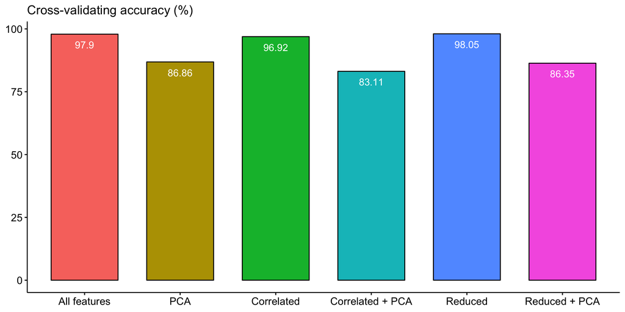

```r
# Cross-validating accuracy chart
gg <- ggbarplot(
  model.summary, x = "model", y = "cv.accuracy",
  title = "Cross-validating accuracy (%)",      # Main title
  fill = "model",                               # Color by groups
  sort.val = "desc",                            # Sort value in descending order
  label = model.summary$cv.accuracy,            # Label values
  lab.pos = "in",                               # Position for labels
  lab.col = "white",                            # Color for labels
  lab.nb.digits = 2,                            # Number of decimal places (round)
  xlab = FALSE,                                 # X-axis labels
  ylab = FALSE,                                 # Y-axis labels
  rotate = FALSE,                               # Rotate vertically
  font.label = list(color = "white", size = 11, vjust = 1.5),
  ggtheme = theme_pubr()                        # ggplot2 theme
)
ggpar(gg, legend = "none", legend.title = "")   # Customize legend
```

Plotting the training times in seconds.

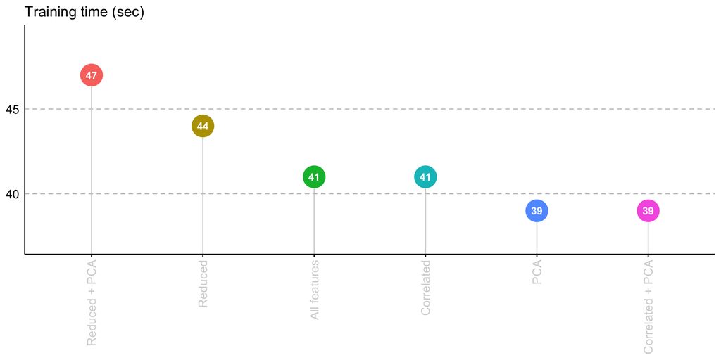

```r
# Training time chart
gg <- ggdotchart(
  model.summary, x = "model", y = "training.time",
  title = "Training time (sec)",                # Main title
  color = "model",                              # Color by groups
  sorting = "descending",                       # Sort value in descending order
  rotate = FALSE,                               # Rotate vertically
  label = model.summary$training.time,          # Label values
  add = "segments",                             # Add lolipop lines
  xlab = FALSE,                                 # X-axis labels
  ylab = FALSE,                                 # Y-axis labels
  dot.size = 10,                                # Large dot size
  y.text.col = TRUE,                            # Color y text by groups
  font.label = list(color = "white", size = 11, face = "bold", vjust = 0.5),
  ggtheme = theme_pubr(),                        # ggplot2 theme
)
ggpar(gg, legend = "none", legend.title = "",  ylim = c(min(model.summary$training.time) * 0.95, max(model.summary$training.time) * 1.05)) + theme_cleveland()
```

## Testing models

Using all of trained models to make predictions on the test dataset (20 observations). The ground truth dataset consist of the expected good values.

```r
# Predictions of the models
test.predictions <- data.frame(row.names = 1:20, stringsAsFactors = TRUE)
test.predictions$ground.truth <- as.factor(c("B", "A", "B", "A", "A", "E", "D", "B", "A", "A", "B", "C", "B", "A", "E", "E", "A", "B", "B", "B"))
test.predictions$all <- predict(model.all.features, testing.data[,-label.index])
test.predictions$all.with.pca <- predict(model.pca.features, testing.data.pca)
test.predictions$correlated <- predict(model.corr.features, testing.data[, most.correlated.outcome.feature.indices])
test.predictions$corr.with.pca <- predict(model.corr.pca.features, testing.data.corr.pca)
test.predictions$reduced <- predict(model.reduced.features, testing.data[, -c(duplicated.feature.indices, label.index)])
test.predictions$reduced.with.pca <- predict(model.reduced.pca.features, testing.data.reduced.pca)
test.predictions
```

```
##    ground.truth all all.with.pca correlated corr.with.pca reduced reduced.with.pca
## 1             B   B            B          B             B       B                B
## 2             A   A            A          A             A       A                A
## 3             B   B            B          B             A       B                A
## 4             A   A            A          A             A       A                A
## 5             A   A            A          A             A       A                A
## 6             E   E            E          E             E       E                C
## 7             D   D            D          D             D       D                D
## 8             B   B            B          B             B       B                B
## 9             A   A            A          A             A       A                A
## 10            A   A            A          A             A       A                A
## 11            B   B            B          B             B       B                B
## 12            C   C            C          C             C       C                C
## 13            B   B            B          B             B       B                B
## 14            A   A            A          A             A       A                A
## 15            E   E            E          E             E       E                E
## 16            E   E            E          E             E       E                E
## 17            A   A            A          A             A       A                A
## 18            B   B            B          B             B       B                B
## 19            B   B            B          B             B       B                B
## 20            B   B            B          B             B       B                B
```

```r
# Calculating testing accuracies
model.summary$testing.accuracy <- c(
  sum(equals(test.predictions$ground.truth, test.predictions$all)) / nrow(test.predictions) * 100,
  sum(equals(test.predictions$ground.truth, test.predictions$all.with.pca)) / nrow(test.predictions) * 100,
  sum(equals(test.predictions$ground.truth, test.predictions$all.with.pca)) / nrow(test.predictions) * 100,
  sum(equals(test.predictions$ground.truth, test.predictions$correlated)) / nrow(test.predictions) * 100,
  sum(equals(test.predictions$ground.truth, test.predictions$corr.with.pca)) / nrow(test.predictions) * 100,
  sum(equals(test.predictions$ground.truth, test.predictions$reduced.with.pca)) / nrow(test.predictions) * 100
)
```

Plotting the final testing accuracy for 20 observations.

[figure not shown]

```r
# Testing accuracy chart
gg <- ggbarplot(
  model.summary, x = "model", y = "testing.accuracy",
  title = "Testing accuracy (%)",                # Main title
  fill = "model",                                # Color by groups
  sort.val = "desc",                             # Sort value in descending order
  label = model.summary$testing.accuracy,        # Label values
  lab.pos = "in",                                # Position for labels
  lab.col = "white",                             # Color for labels
  lab.nb.digits = 2,                             # Number of decimal places (round)
  xlab = FALSE,                                  # X-axis labels
  ylab = FALSE,                                  # Y-axis labels
  rotate = FALSE,                                # Rotate vertically
  font.label = list(color = "white", size = 11, vjust = 1.5),
  ggtheme = theme_pubr()                         # ggplot2 theme
)
ggpar(gg, legend = "none", legend.title = "")    # Customize legend
```

## Conclusion

Using all features to train the model give us an appropriate cross-validating and testing accuracy.  
However the reduced features provide more validating accuracy.

Plotting the error rate tendency of the first trained model.

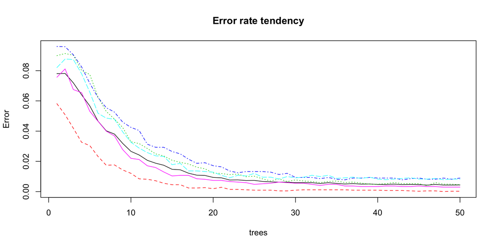

```r
plot(model.all.features, main = "Error rate tendency")
```